```python
import pandas as pd
import numpy as np
import math
import sys

import matplotlib as mlp
import matplotlib.pyplot as plt
import seaborn as sns
```

# Comparing strategies for paying off debt across multiple accounts

When I look online I see two different strategies for efficiently paying off multi-account debt: Snowball and Avalanche. While I could find free online debt payoff simulators for single account debt, I couldn't easily find any online tools that could simulate these strategies across multiple accounts. So I decided to write my own simulator. On this page, we look at only one particular set of simulation parameters (one example set of accounts). A useful future project would be compare the payoff strategies across multiple debt account setups. In addition, these accounts do not accrue additional balances. See the next steps section at the end more features I would like to add if I kept working on this project.

## Payoff Strategies compared:

1. **Snowball** : After paying off the minimum payments for all account, allocate the remaining money to the account with the *lowest balance first*
2. **Avalanche** : After paying off the minimum payments for all account, allocate the remaining money to the account with the *highest interest rate first*

## Simulation details

### Simulation parameters

This simulation on this page simulates paying off 3 different accounts, but the code is extensible enough to work across multiple accounts

#### 1. Example debt accounts

```python
loan_df = pd.read_csv('./data/loans.csv', sep = '\t')
num_cards = loan_df.shape[0]
loan_df
```

|  | Loan Name | Loan Amount | APR |
| --- | --- | --- | --- |
| 0 | Card 1 | 10000 | 25 |
| 1 | Card 2 | 5000 | 20 |
| 2 | Card 3 | 9000 | 10 |

**What is APR ?** APR stands for annunal percentage rate. You can read more about it [here](https://www.creditkarma.com/advice/i/what-is-apr/)

#### 2. Minimum monthly payment rules

Every debt account will have a minumum monthly payment lieu of which you will acrrue late payment fees. Right now, I've decided to keep things simple and use the following rule:

```
The minimum payment is either the full balance if the balance is less than $25, or 2% of balance + interest
```

Every card seems to have different minimum payment rules, but all of them ensure that card payments do not continue indefinitely. More about minimum payments [here](https://www.creditcards.com/credit-card-news/minimum-credit_card-payments-survey-1276.php)

#### 3. Montly budget

This is a fixed pool of money available for paying off cards.

```python
MONTHLY_BUDGET = 1000
```

**Note on "slack"** I use the term slack to denote the available money after all account's minimum monthly payments have been made.

#### 4. Max Credit Limit

This is a fixed upper limit of available credit. It is mostly used for the comparison at the end and is not used in the simulation itself.

```python
CREDIT_LIMIT = 25000
```

## Simulation functions

```python
def calc_across_cards(month_row, col_name, func):
    vals = []
    for card_num in range(0, num_cards):
        vals.append(float(month_row[str(card_num)+'_'+col_name]))
    return func(vals)

def sort_cards_row(month_row, card_attr, ascending):
    '''
    Given a month to look at, a card attribute and a sorting order; returns a list of card indexes in that order
    '''
    unsorted = []
    for card_num in range(num_cards):
        unsorted.append((card_num, month_row[str(card_num)+'_'+card_attr]))
    return [x[0] for x in (sorted(unsorted, key=lambda x : x[1], reverse=(not ascending)))]

def calc_total_interest(sim_df):
    total_interest = 0
    for card_num in range(num_cards):
        total_interest += sim_df[str(card_num)+'_interest']
    return round(np.sum(total_interest),2)

def calc_total_payments(sim_df):
    total_payments = 0
    for card_num in range(num_cards):
        total_payments += sim_df[str(card_num)+'_interest'] + sim_df[str(card_num)+'_principal']
    return round(np.sum(total_payments),2)

def allocate_slack_snowball(curr_month_row, curr_slack):
    for card_num in sort_cards_row(curr_month_row, 'balance', True):
        if curr_slack == 0:
            return curr_slack
        net_balance = curr_month_row[str(card_num)+'_balance'] - \
            (curr_month_row[str(card_num)+'_principal'] + curr_month_row[str(card_num)+'_interest'])
        if net_balance <= 0:
            continue
        else:
            if curr_slack <= net_balance:
                curr_month_row[str(card_num)+'_principal'] += curr_slack
                curr_slack = 0
                break
            else:
                curr_month_row[str(card_num)+'_principal'] += net_balance
                curr_slack -= net_balance
    return (curr_month_row, curr_slack)


def allocate_slack_avalanche(curr_month_row, curr_slack):
    for card_num in sort_cards_row(curr_month_row, 'interest', False):
        if curr_slack == 0:
            return curr_slack
        net_balance = curr_month_row[str(card_num)+'_balance'] - \
            (curr_month_row[str(card_num)+'_principal'] + curr_month_row[str(card_num)+'_interest'])
        if net_balance <= 0:
            continue
        else:
            if curr_slack <= net_balance:
                curr_month_row[str(card_num)+'_principal'] += curr_slack
                curr_slack = 0
                break
            else:
                curr_month_row[str(card_num)+'_principal'] += net_balance
                curr_slack -= net_balance
    return (curr_month_row, curr_slack)

def run_simulation(strat_name, allocation_strategy):
    # Starting conditions

    sim_df = pd.DataFrame()
    sim_cols = ['balance', 'min_payment', 'principal', 'interest', 'payment']

    init_row = {'month' : 0, 'budget' : MONTHLY_BUDGET}

    for idx, row in loan_df.iterrows():
        card_num = str(idx)+'_'
        init_row[card_num+'balance'] = row['Loan Amount']
        init_row[card_num+'min_payment'] = 0
        init_row[card_num+'principal'] = 0
        init_row[card_num+'interest'] = 0

    sim_df = sim_df.append(init_row, ignore_index=True)
    sim_df['balances'] = calc_across_cards(init_row, 'balance', np.sum)
    sim_df['slack'] = sim_df['budget'] - calc_across_cards(init_row, 'min_payment', np.sum)

    curr_month = 1
    curr_balances = sim_df['balances'][0]

    # Simulation Loop
    print('Paying off loans using the {} strategy'.format(strat_name))

    while(sim_df['balances'][curr_month-1] > 0):
        curr_row = {'month' : curr_month}
        prev_month = sim_df.loc[curr_month - 1]

        # TODO Make the min_payments per card dynamic, for now it is either the full balance if it is less than
        # $25, or flat 2% of balance + interest
        tot_min_payment = 0
        for card_num in range(num_cards):
            card_str = str(card_num) + '_'
            curr_row[card_str+'balance'] = prev_month[card_str+'balance'] - prev_month[card_str+'principal']
            curr_balance = curr_row[card_str+'balance']
            curr_row[card_str+'interest'] = round(curr_balance * (loan_df['APR'][card_num] / 1200) , 2)
            if curr_balance < 25:
                curr_row[card_str+'min_payment'] = curr_balance
                curr_row[card_str+'principal'] = curr_balance
                curr_row[card_str+'interest'] = 0
            else :
                curr_row[card_str+'min_payment'] = round(curr_balance*0.02 + curr_row[card_str+'interest'], 2)
            tot_min_payment += curr_row[card_str+'min_payment']
            curr_row[card_str+'principal'] = curr_row[card_str+'min_payment'] - curr_row[card_str+'interest']
            # curr_row[card_str+'payment'] = curr_row[card_str+'min_payment']

        curr_row['budget'] = prev_month['budget']
        curr_row['slack'] = curr_slack = curr_row['budget'] - tot_min_payment

        curr_row, curr_slack = allocation_strategy(curr_row, curr_slack)

        sim_df = sim_df.append(curr_row, ignore_index=True)
        sim_df['balances'][curr_month] = calc_across_cards(sim_df.iloc[curr_month], 'balance', np.sum)

        if curr_slack > 0:
            print('Done simulating {} months'.format(curr_month))
            print('Done running the simulation. Leftover slack:', round(curr_slack,2))
            break
        if curr_month >= 720:
            print('Simulation stopped: exceeded simulation max length of 720 months')
            break
        if curr_month %5 == 0:
            print('Done simulating {} months'.format(curr_month))

        curr_month += 1

    sim_df['avail_credit'] = CREDIT_LIMIT - sim_df['balances']
    return sim_df, curr_month
```

## Running the simulation

### 1. Using Snowball strategy first

After paying off the minimum payments for all account, allocate the remaining money to the account with the *lowest balance first*

```python
snow_df, snow_run_time = run_simulation('Snowball', allocate_slack_snowball)
print('Sim Run Time {} months'.format(snow_run_time))
snow_total_interest = calc_total_interest(snow_df)
print('Total Interest Paid: ', snow_total_interest)
snow_total_paid = calc_total_payments(snow_df)
print('Total Payments Made: ', snow_total_paid)
```

```
Paying off loans using the Snowball strategy
Done simulating 5 months
Done simulating 10 months
Done simulating 15 months
Done simulating 20 months
Done simulating 25 months
Done simulating 30 months
Done simulating 31 months
Done running the simulation. Leftover slack: 639.96
Sim Run Time 31 months
Total Interest Paid:  6367.54
Total Payments Made:  30360.04
```

### 2. Next, Avalanche strategy

After paying off the minimum payments for all account, allocate the remaining money to the account with the *highest interest rate first*

```python
aval_df, aval_run_time = run_simulation('Avalanche', allocate_slack_avalanche)
print('Sim Run Time {} months'.format(aval_run_time))
aval_total_interest = calc_total_interest(aval_df)
print('Total Interest Paid: ', aval_total_interest)
aval_total_paid = calc_total_payments(aval_df)
print('Total Payments Made: ', aval_total_paid)
```

```
Paying off loans using the Avalanche strategy
Done simulating 5 months
Done simulating 10 months
Done simulating 15 months
Done simulating 20 months
Done simulating 25 months
Done simulating 30 months
Done running the simulation. Leftover slack: 357.55
Sim Run Time 30 months
Total Interest Paid:  5650.28
Total Payments Made:  29642.45
```

## **Visualizing and comparing strategies**

#### Payment period

```python
print('Payment period for snowball strategy is {} months, payment period for avalanche strategy is {} months. Difference: {} month(s)'.format(snow_run_time, aval_run_time, snow_run_time - aval_run_time))
```

```
Payment period for snowball strategy is 31 months, payment period for avalanche strategy is 30 months. Difference: 1 month(s)
```

#### Total Amount paid

```python
print('Total payments made for snowball strategy is {}, total payments made for avalanche strategy is {}. Difference: {}'.format(snow_total_paid, aval_total_paid, round(snow_total_paid - aval_total_paid, 2)))
```

```
Total payments made for snowball strategy is 30360.04, total payments made for avalanche strategy is 29642.45. Difference: 717.59
```

#### Change in available credit across time

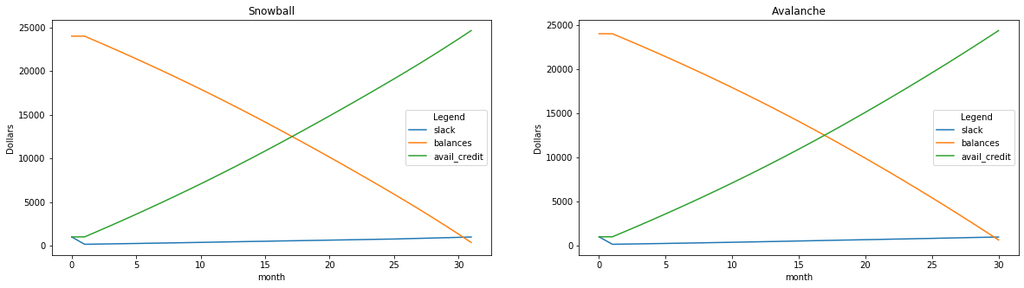

```python
%matplotlib inline
fig, ax = plt.subplots(1,2,figsize=(20, 5))

snow_viz_df = snow_df[['month', 'slack', 'balances', 'avail_credit']].melt(id_vars='month', var_name='Legend', value_name='Dollars')
# viz_df
ax[0] = sns.lineplot(x="month", y="Dollars", hue='Legend', data=snow_viz_df, ax=ax[0])
ax[0].set_title('Snowball')
aval_viz_df = aval_df[['month', 'slack', 'balances', 'avail_credit']].melt(id_vars='month', var_name='Legend', value_name='Dollars')
# viz_df
ax[1] = sns.lineplot(x="month", y="Dollars", hue='Legend', data=aval_viz_df, ax=ax[1])
_ = ax[1].set_title('Avalanche')
```

As you can see, it is difficult to compare these plots just by eyeballing them. Instead, lets look at the differences in slack, balances and available credit between these two strategies as this simulation runs

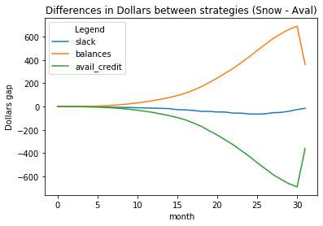

```python
snow_viz_df['join_key'] = (snow_viz_df['month'].astype(str) + snow_viz_df['Legend']).astype(str)
aval_viz_df['join_key'] = (aval_viz_df['month'].astype(str) + aval_viz_df['Legend']).astype(str)

comp_viz_df = snow_viz_df.merge(aval_viz_df, on=['join_key'], how='left').drop(columns=['month_y', 'join_key', 'Legend_y'])\
    .rename(columns={'month_x' : 'month', 'Legend_x' : 'Legend'})
comp_viz_df.loc[(comp_viz_df['Legend'] == 'slack') & (comp_viz_df['Dollars_x'].isna()), 'Dollars_x'] = MONTHLY_BUDGET
comp_viz_df.loc[(comp_viz_df['Legend'] == 'slack') & (comp_viz_df['Dollars_y'].isna()), 'Dollars_y'] = MONTHLY_BUDGET
comp_viz_df.loc[(comp_viz_df['Legend'] == 'balances') & (comp_viz_df['Dollars_x'].isna()), 'Dollars_x'] = 0
comp_viz_df.loc[(comp_viz_df['Legend'] == 'balances') & (comp_viz_df['Dollars_y'].isna()), 'Dollars_y'] = 0
comp_viz_df.loc[(comp_viz_df['Legend'] == 'avail_credit') & (comp_viz_df['Dollars_x'].isna()), 'Dollars_x'] = CREDIT_LIMIT
comp_viz_df.loc[(comp_viz_df['Legend'] == 'avail_credit') & (comp_viz_df['Dollars_y'].isna()), 'Dollars_y'] = CREDIT_LIMIT
comp_viz_df['Dollars gap'] = comp_viz_df['Dollars_x'] - comp_viz_df['Dollars_y']

ax = sns.lineplot(x="month", y="Dollars gap", hue='Legend', data=comp_viz_df)
_ = ax.set_title('Differences in Dollars between strategies (Snow - Aval)')
```

In this plot, we subtracted the Avalance simulation amounts *from* the snowball simulation amounts (Snowball - Avalanche). The spike at the end is because the avalance simulation finished before the snowball simulation.

## **Conclusion**

Based on this example alone, it appears that the avalance method of paying off loans is superior compared to the snowball method. It results in both overall lower interest payments as well as freeing up credit faster. I have manually played around with the simulation parameters, and it seems that the avalanche method is always superior. In any case, using this code, you should be able to compare the two methods for yourself. (atleast one simulation at a time)

#### Next Steps

1. Explore the parameter space of this simulation and see which strategy is better by running mulitple simultions with multiple generated parameters.
2. Allow the specification of events that occur during the run time of the simulation:

   a. Change in monthly budget

   b. Change in APR

   c. Change in balances on accounts
3. Come up with a better visualization to look at the simulation results on the same chart